# DSCI 101 Project

Josie Peterburs

2023-03-28

```r
library(tidyverse)
library(mdsr)
library(lubridate)
# team id and things
MTeams <- read.csv("C:/Users/gigip/Downloads/march-machine-learning-mania-2023/MTeams.csv")
WTeams <- read.csv("C:/Users/gigip/Downloads/march-machine-learning-mania-2023/WTeams.csv")

# regular season
MRegularSeasonDetailedResults <- read.csv("C:/Users/gigip/Downloads/march-machine-learning-mania-2023/MRegularSeasonDetailedResults.csv")
WRegularSeasonDetailedResults <- read.csv("C:/Users/gigip/Downloads/march-machine-learning-mania-2023/WRegularSeasonDetailedResults.csv")

# tourney background
MNCAATourneySeeds <- read.csv("C:/Users/gigip/Downloads/march-machine-learning-mania-2023/MNCAATourneySeeds.csv")
WNCAATourneySeeds <- read.csv("C:/Users/gigip/Downloads/march-machine-learning-mania-2023/WNCAATourneySeeds.csv")

# regions
MSeasons <- read.csv("C:/Users/gigip/Downloads/march-machine-learning-mania-2023/MSeasons.csv")
WSeasons <- read.csv("C:/Users/gigip/Downloads/march-machine-learning-mania-2023/WSeasons.csv")

# tournament results
MNCAATourneyDetailedResults <- read.csv("C:/Users/gigip/Downloads/march-machine-learning-mania-2023/MNCAATourneyDetailedResults.csv")
WNCAATourneyDetailedResults <- read.csv("C:/Users/gigip/Downloads/march-machine-learning-mania-2023/WNCAATourneyDetailedResults.csv")

# other
conferences <- read.csv("C:/Users/gigip/Downloads/march-machine-learning-mania-2023/Conferences.csv")
MTeamConferences <- read.csv("C:/Users/gigip/Downloads/march-machine-learning-mania-2023/MTeamConferences.csv")
WTeamConferences <- read.csv("C:/Users/gigip/Downloads/march-machine-learning-mania-2023/WTeamConferences.csv")
```

## Q1: What team has the most average wins per season for their time as a D1 team since 2003? (Do men and women separately)

Men: Gonzaga with 26.8 wins.

```r
# detailed regular season results start in 2003 so find d1 years since 2003
m_time_as_d1 <- MTeams %>% filter(LastD1Season >= 2003) %>% mutate(d1years_since2003 = ifelse(FirstD1Season < 2003, 21, LastD1Season - FirstD1Season + 1))

# find total number of wins for each team per season. detailed results begin in 2003, so there are at most 21 seasons per team.
m_num_wins_per_season <- MRegularSeasonDetailedResults %>% group_by(Season, WTeamID) %>% summarize(numwins = n())
# join tables by TeamID and get average wins (total wins over the years divided by number of years)
m_wins_and_d1_seasons <- m_num_wins_per_season %>%
  inner_join(m_time_as_d1, by = c("WTeamID" = "TeamID")) %>% select(Season, numwins, TeamName, d1years_since2003) %>% group_by(TeamName) %>% summarize(avg_win_per_season = sum(numwins) / d1years_since2003) %>%  arrange(-avg_win_per_season) %>% unique()
m_wins_and_d1_seasons %>% head(10)
```

```
## # A tibble: 10 × 2
## # Groups:   TeamName [10]
##    TeamName       avg_win_per_season
##    <chr>                       <dbl>
##  1 Gonzaga                      26.8
##  2 Kansas                       26.4
##  3 Duke                         26.1
##  4 Kentucky                     24.5
##  5 Arizona                      23.6
##  6 Memphis                      23.6
##  7 North Carolina               23.5
##  8 VCU                          23
##  9 Villanova                    22.8
## 10 Michigan St                  22.8
```

Women: Connecticut with 30.1 wins

```r
# don't have d1 years for women, so will have to assume all teams have been D1 since 2010 (when the regular season data begins). we want best time averaged over the years, so this hopefully will not affect the major teams
w_time_as_d1 = WTeams %>% mutate(d1years = 2023 - 2010 + 1)

w_num_wins_per_season <- WRegularSeasonDetailedResults %>% group_by(Season, WTeamID) %>% summarize(numwins = n())
w_wins_and_d1_seasons <- w_num_wins_per_season %>%
  inner_join(w_time_as_d1, by = c("WTeamID" = "TeamID")) %>% select(Season, numwins, TeamName, d1years) %>% group_by(TeamName) %>% summarize(avg_win_per_season = sum(numwins) / d1years) %>%  arrange(-avg_win_per_season) %>% unique()
# Connecticut is the top team, which makes sense because of their super long win-streak even if some of the teams were not D1 for all 14 seasons.
w_wins_and_d1_seasons %>% head(10)
```

```
## # A tibble: 10 × 2
## # Groups:   TeamName [10]
##    TeamName       avg_win_per_season
##    <chr>                       <dbl>
##  1 Connecticut                  30.1
##  2 Baylor                       28.6
##  3 Stanford                     27.5
##  4 FL Gulf Coast                26.4
##  5 Notre Dame                   26.2
##  6 Gonzaga                      26
##  7 Maryland                     25.6
##  8 South Carolina               25.2
##  9 WI Green Bay                 24.9
## 10 Louisville                   24.6
```

## Q2: My dad always says that free throws win games. Does the team that makes more free throws (by number and by %) in an individual game typically win? In other words, what is the probability that a team wins an individual game given that they made more free throws (count and percentage)?

Men: Count - 0.6768. Percentage - 0.5761.

```r
# by number of free throws
m_count_ft <- MRegularSeasonDetailedResults %>% select(Season, WFTM, LFTM) %>% na.omit() %>% mutate(m_team_with_more_ft = ifelse(WFTM > LFTM, 1, 0))
m_count_ft %>% summarize(prob = mean(m_team_with_more_ft))
```

```
##        prob
## 1 0.6768122
```

```r
# by percentage of free throws made
m_prct_ft <- MRegularSeasonDetailedResults %>% select(Season, WFTM, WFTA, LFTM, LFTA) %>% na.omit() %>% mutate(m_wteam_prct = WFTM / WFTA, m_lteam_prct = LFTM / LFTA, m_higher_ft_prct = ifelse(m_wteam_prct > m_lteam_prct, 1, 0))
m_prct_ft %>% summarize(prob = mean(m_higher_ft_prct, na.rm = TRUE))
```

```
##       prob
## 1 0.576068
```

Women: Count - 0.6623. Percentage - 0.5660.

```r
# by number of free throws
w_count_ft <- WRegularSeasonDetailedResults %>% select(Season, WFTM, LFTM) %>% na.omit() %>% mutate(w_team_with_more_ft = ifelse(WFTM > LFTM, 1, 0))
w_count_ft %>% summarize(prob = mean(w_team_with_more_ft))
```

```
##        prob
## 1 0.6622635
```

```r
# by percentage of free throws made
w_prct_ft <- WRegularSeasonDetailedResults %>% select(Season, WFTM, WFTA, LFTM, LFTA) %>% na.omit() %>% mutate(w_wteam_prct = WFTM / WFTA, w_lteam_prct = LFTM / LFTA, w_higher_ft_prct = ifelse(w_wteam_prct > w_lteam_prct, 1, 0))
w_prct_ft %>% summarize(prob = mean(w_higher_ft_prct, na.rm = TRUE))
```

```
##        prob
## 1 0.5660028
```

## Q2.5: Plot FT percentage and winning percentage on a scatter plot. Facet by year and color-code if the team made the March Madness tournament.

Men:

```r
# win percentage
m_win <- MRegularSeasonDetailedResults %>% group_by(Season, WTeamID) %>% summarize(totalwins = n())
m_loss <- MRegularSeasonDetailedResults %>% group_by(Season, LTeamID) %>% summarize(totalloss = n())
m_combined_games <- m_win %>% left_join(m_loss, by = c("WTeamID" = "LTeamID", "Season" = "Season")) %>% mutate(totalgames = totalwins + totalloss, win_prct = totalwins / totalgames) %>% na.omit() %>% select(Season, WTeamID, win_prct)
m_combined_games %>% head()
```

```
## # A tibble: 6 × 3
## # Groups:   Season [1]
##   Season WTeamID win_prct
##    <int>   <int>    <dbl>
## 1   2003    1102    0.429
## 2   2003    1103    0.481
## 3   2003    1104    0.607
## 4   2003    1105    0.269
## 5   2003    1106    0.464
## 6   2003    1107    0.25
```

```r
# freethrows
m_winningteamFT <- MRegularSeasonDetailedResults %>% group_by(Season, WTeamID) %>% summarize(WtotalFTM = sum(WFTM), WtotalFTA = sum(WFTA))
m_losingteamFT <- MRegularSeasonDetailedResults %>% group_by(Season, LTeamID) %>% summarize(LtotalFTM = sum(LFTM), LtotalFTA = sum(LFTA))
m_totalFT <- m_winningteamFT %>% left_join(m_losingteamFT, by = c("WTeamID" = "LTeamID", "Season" = "Season")) %>% na.omit() %>% mutate(totalFTM = WtotalFTM + LtotalFTM, totalFTA = WtotalFTA + LtotalFTA, ft_prct = totalFTM / totalFTA) %>% select(Season, WTeamID, totalFTM, totalFTA, ft_prct) %>% select(Season, WTeamID, ft_prct)
m_totalFT %>% head()
```

```
## # A tibble: 6 × 3
## # Groups:   Season [1]
##   Season WTeamID ft_prct
##    <int>   <int>   <dbl>
## 1   2003    1102   0.651
## 2   2003    1103   0.736
## 3   2003    1104   0.710
## 4   2003    1105   0.706
## 5   2003    1106   0.646
## 6   2003    1107   0.734
```

```r
# did the team make the ncaa tournament
m_tourney_teams <- MNCAATourneySeeds %>% filter(Season >= '2003') %>% mutate(made_tourney = "yes")

# combine
m_ft_and_wins <- m_combined_games %>% left_join(m_totalFT, by = c("WTeamID" = "WTeamID", "Season" = "Season")) %>% left_join(m_tourney_teams, by = c("Season" = "Season", "WTeamID" = "TeamID")) %>% select(Season, WTeamID, win_prct, ft_prct, made_tourney)
m_ft_and_wins %>% head()
```

```
## # A tibble: 6 × 5
## # Groups:   Season [1]
##   Season WTeamID win_prct ft_prct made_tourney
##    <int>   <int>    <dbl>   <dbl> <chr>
## 1   2003    1102    0.429   0.651 <NA>
## 2   2003    1103    0.481   0.736 <NA>
## 3   2003    1104    0.607   0.710 yes
## 4   2003    1105    0.269   0.706 <NA>
## 5   2003    1106    0.464   0.646 <NA>
## 6   2003    1107    0.25    0.734 <NA>
```

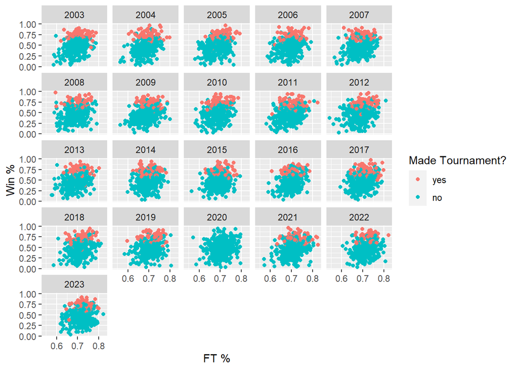

```r
m_ft_and_wins[is.na(m_ft_and_wins)] <- "no"

m_ft_and_wins %>% ggplot(aes(x = ft_prct, y = win_prct, color = fct_relevel(made_tourney, "yes"))) + geom_point() + xlab("FT %") + ylab("Win %") + labs(color = "Made Tournament?") + facet_wrap(~ Season)
```

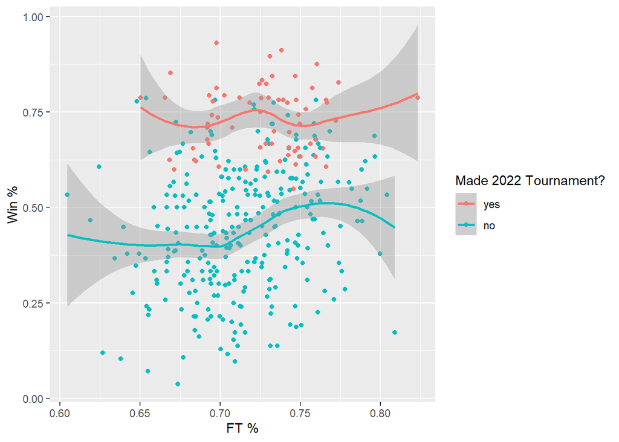

```r
# look at one specific year
m_ft_and_wins %>% filter(Season == '2022') %>% ggplot(aes(x = ft_prct, y = win_prct, color = fct_relevel(made_tourney, "yes"))) + geom_point() + geom_smooth() + xlab("FT %") + ylab("Win %") + labs(color = "Made 2022 Tournament?")
```

Women:

```r
# win percentage
w_win <- WRegularSeasonDetailedResults %>% group_by(Season, WTeamID) %>% summarize(totalwins = n())
w_loss <- WRegularSeasonDetailedResults %>% group_by(Season, LTeamID) %>% summarize(totalloss = n())
w_combined_games <- w_win %>% left_join(w_loss, by = c("WTeamID" = "LTeamID", "Season" = "Season")) %>% mutate(totalgames = totalwins + totalloss, win_prct = totalwins / totalgames) %>% na.omit() %>% select(Season, WTeamID, win_prct)
w_combined_games %>% head()
```

```
## # A tibble: 6 × 3
## # Groups:   Season [1]
##   Season WTeamID win_prct
##    <int>   <int>    <dbl>
## 1   2010    3102   0.0357
## 2   2010    3103   0.567
## 3   2010    3104   0.379
## 4   2010    3105   0.519
## 5   2010    3106   0.414
## 6   2010    3107   0.367
```

```r
# freethrows
w_winningteamFT <- WRegularSeasonDetailedResults %>% group_by(Season, WTeamID) %>% summarize(WtotalFTM = sum(WFTM), WtotalFTA = sum(WFTA))
w_losingteamFT <- WRegularSeasonDetailedResults %>% group_by(Season, LTeamID) %>% summarize(LtotalFTM = sum(LFTM), LtotalFTA = sum(LFTA))
w_totalFT <- w_winningteamFT %>% left_join(w_losingteamFT, by = c("WTeamID" = "LTeamID", "Season" = "Season")) %>% na.omit() %>% mutate(totalFTM = WtotalFTM + LtotalFTM, totalFTA = WtotalFTA + LtotalFTA, ft_prct = totalFTM / totalFTA) %>% select(Season, WTeamID, totalFTM, totalFTA, ft_prct) %>% select(Season, WTeamID, ft_prct)
w_totalFT %>% head()
```

```
## # A tibble: 6 × 3
## # Groups:   Season [1]
##   Season WTeamID ft_prct
##    <int>   <int>   <dbl>
## 1   2010    3102   0.678
## 2   2010    3103   0.706
## 3   2010    3104   0.616
## 4   2010    3105   0.699
## 5   2010    3106   0.648
## 6   2010    3107   0.629
```

```r
# did the team make the ncaa tournament
w_tourney_teams <- WNCAATourneySeeds %>% filter(Season >= '2010') %>% mutate(made_tourney = "yes")

# combine
w_ft_and_wins <- w_combined_games %>% left_join(w_totalFT, by = c("WTeamID" = "WTeamID", "Season" = "Season")) %>% left_join(w_tourney_teams, by = c("Season" = "Season", "WTeamID" = "TeamID")) %>% select(Season, WTeamID, win_prct, ft_prct, made_tourney)
w_ft_and_wins %>% head()
```

```
## # A tibble: 6 × 5
## # Groups:   Season [1]
##   Season WTeamID win_prct ft_prct made_tourney
##    <int>   <int>    <dbl>   <dbl> <chr>
## 1   2010    3102   0.0357   0.678 <NA>
## 2   2010    3103   0.567    0.706 <NA>
## 3   2010    3104   0.379    0.616 <NA>
## 4   2010    3105   0.519    0.699 <NA>
## 5   2010    3106   0.414    0.648 <NA>
## 6   2010    3107   0.367    0.629 <NA>
```

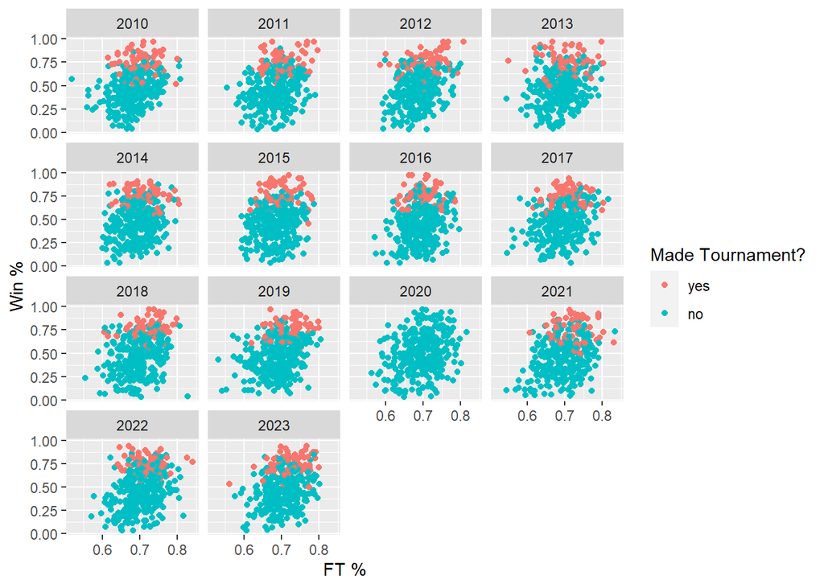

```r
w_ft_and_wins[is.na(w_ft_and_wins)] <- "no"

w_ft_and_wins %>% ggplot(aes(x = ft_prct, y = win_prct, color = fct_relevel(made_tourney, "yes"))) + geom_point() + xlab("FT %") + ylab("Win %") + labs(color = "Made Tournament?") + facet_wrap(~ Season)
```

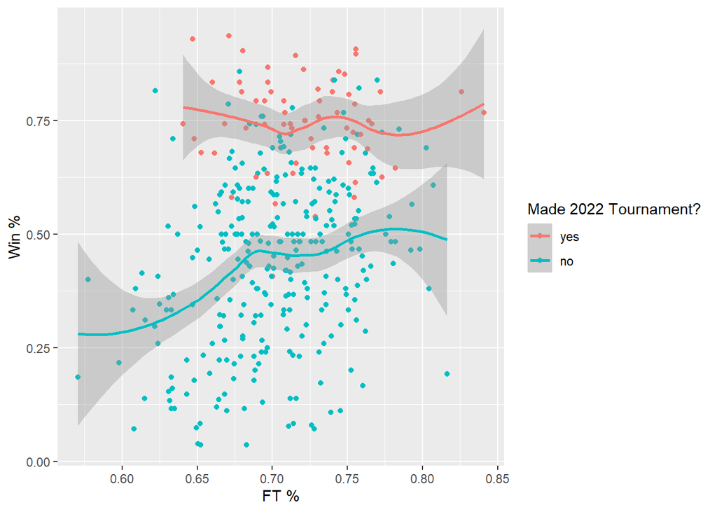

```r
# look at one specific year
w_ft_and_wins %>% filter(Season == '2022') %>% ggplot(aes(x = ft_prct, y = win_prct, color = fct_relevel(made_tourney, "yes"))) + geom_point() + geom_smooth() + xlab("FT %") + ylab("Win %") + labs(color = "Made 2022 Tournament?")
```

## Q3: Was there a difference in score, fouls, assists, and three point shooting percentage by conference in the 21-22 season? Plot each element on sied-by-side boxplots to compare conferences.

(Top conferences from WarrenNolan.com; 2022 season for men and women)

- Men: West Coast, Atlantic 10, Mountain West, American Athletic, Pac-12, ACC, Big East, SEC, Big Ten, Big 12
- Women: Missouri Valley, Atlantic 10, Big East, West Coast, American Athletic, Big Ten, ACC, Big 12, Pac-12, SEC

Men (Top 10 Conferences):

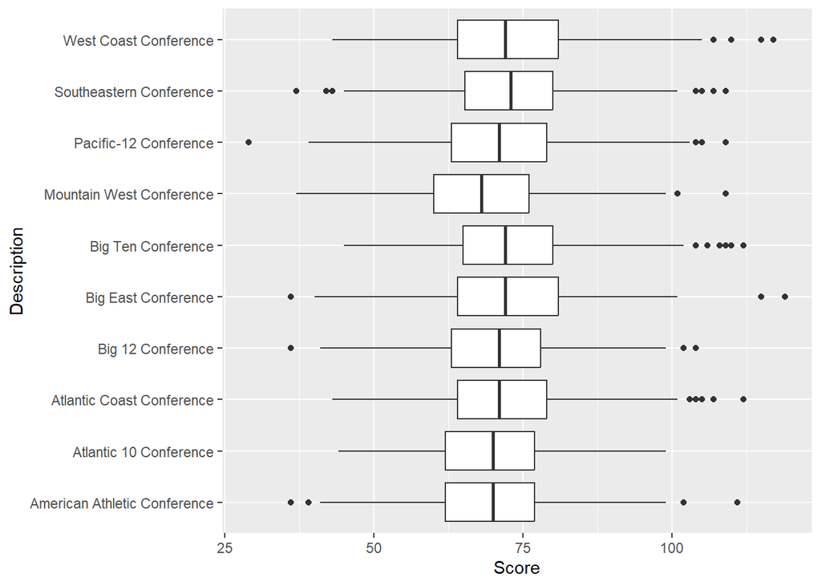

```r
m_topconf <- c("West Coast Conference", "Atlantic 10 Conference", "Mountain West Conference", "American Athletic Conference", "Pacific-12 Conference", "Atlantic Coast Conference", "Big East Conference", "Southeastern Conference", "Big Ten Conference", "Big 12 Conference")

m_conferences10 <- conferences %>% filter(Description %in% m_topconf)
m_confabbrevs <- m_conferences10 %>% select(ConfAbbrev)
m_confabbrevs2 <- c("a_ten", "aac", "acc", "big_east", "big_ten", "big_twelve", "mwc", "pac_twelve", "sec", "wcc")

m_teams <- MTeamConferences %>% filter(ConfAbbrev %in% m_confabbrevs2, Season == "2022") %>% select(TeamID, ConfAbbrev)

m_win_gamedetails <- MRegularSeasonDetailedResults %>% filter(Season == "2022") %>% select(WTeamID, WScore, WPF, WAst, WFGM3, WFGA3) %>% inner_join(m_teams, by = c("WTeamID" = "TeamID")) %>% left_join(m_conferences10, by = c("ConfAbbrev" = "ConfAbbrev")) %>%
        rename("TeamID" = "WTeamID",
               "Score" = "WScore",
               "Fouls" = "WPF",
               "Assists" = "WAst",
               "FGM3" = "WFGM3",
               "FGA3" = "WFGA3")

m_lose_gamedetails <- MRegularSeasonDetailedResults %>% filter(Season == "2022") %>% select(LTeamID, LScore, LPF, LAst, LFGM3, LFGA3) %>% inner_join(m_teams, by = c("LTeamID" = "TeamID")) %>% left_join(m_conferences10, by = c("ConfAbbrev" = "ConfAbbrev")) %>%
        rename("TeamID" = "LTeamID",
               "Score" = "LScore",
               "Fouls" = "LPF",
               "Assists" = "LAst",
               "FGM3" = "LFGM3",
               "FGA3" = "LFGA3")

m_all_gamedetails <- rbind(m_win_gamedetails, m_lose_gamedetails) %>% mutate(Three_Point_Prct = FGM3 / FGA3)

# Score
m_all_gamedetails %>% ggplot(aes(x = Description, y = Score)) + geom_boxplot() + coord_flip()
```

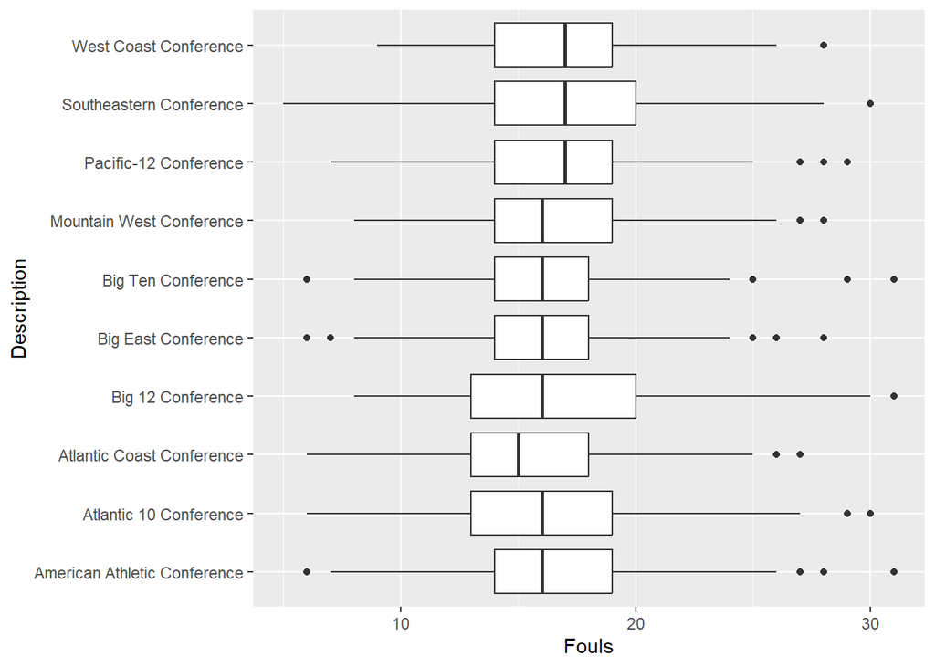

```r
# Fouls
m_all_gamedetails %>% ggplot(aes(x = Description, y = Fouls)) + geom_boxplot() + coord_flip()
```

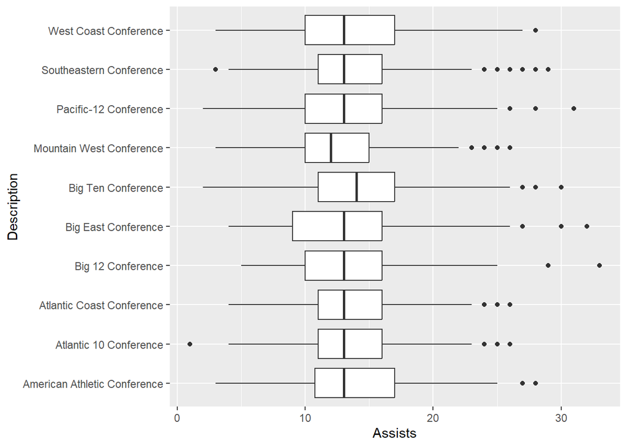

```r
# Assists
m_all_gamedetails %>% ggplot(aes(x = Description, y = Assists)) + geom_boxplot() + coord_flip()
```

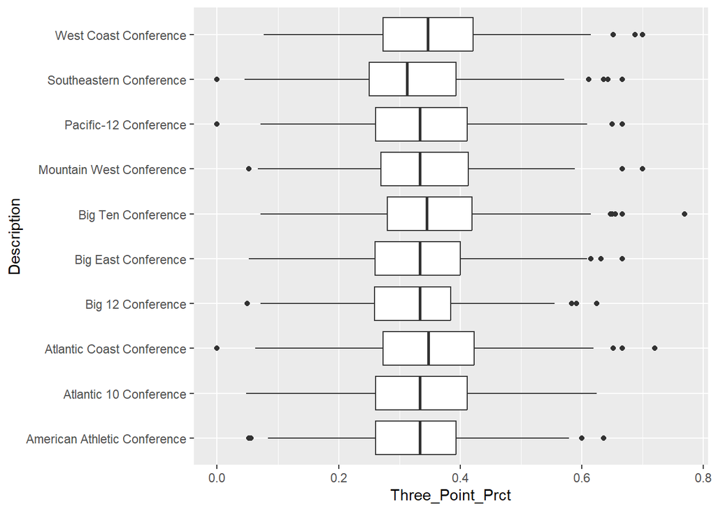

```r
# 3-Point Shooting %
m_all_gamedetails %>% ggplot(aes(x = Description, y = Three_Point_Prct)) + geom_boxplot() + coord_flip()
```

```r
# overall averages
m_category_avgs <- m_all_gamedetails %>% group_by(Description) %>% summarize(score = mean(Score), fouls = mean(Fouls), assists = mean(Assists), threept = mean(FGM3 / FGA3))
m_category_avgs
```

```
## # A tibble: 10 × 5
##    Description                  score fouls assists threept
##    <chr>                        <dbl> <dbl>   <dbl>   <dbl>
##  1 American Athletic Conference  69.8  16.8    13.6   0.329
##  2 Atlantic 10 Conference        69.7  16.1    13.4   0.341
##  3 Atlantic Coast Conference     71.6  15.3    13.7   0.348
##  4 Big 12 Conference             70.5  16.6    13.6   0.327
##  5 Big East Conference           72.3  16.1    13.3   0.332
##  6 Big Ten Conference            72.8  16.1    14.0   0.349
##  7 Mountain West Conference      68.4  16.7    12.8   0.340
##  8 Pacific-12 Conference         71.1  16.8    13.1   0.335
##  9 Southeastern Conference       72.7  17.1    13.7   0.321
## 10 West Coast Conference         72.3  16.7    13.3   0.349
```

Women (Top Ten Conferences):

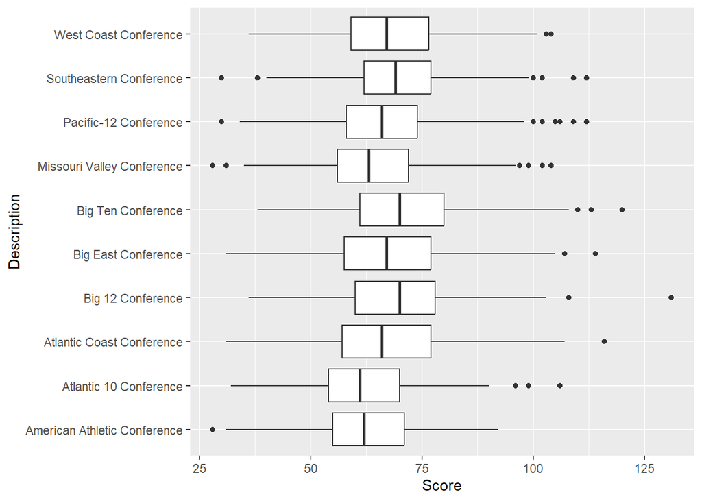

```r
w_topconf <- c("Missouri Valley Conference", "Atlantic 10 Conference", "Big East Conference", "West Coast Conference", "American Athletic Conference", "Big Ten Conference", "Atlantic Coast Conference", "Big 12 Conference", "Pacific-12 Conference", "Southeastern Conference")

w_conferences10 <- conferences %>% filter(Description %in% w_topconf)
w_confabbrevs <- w_conferences10 %>% select(ConfAbbrev)
w_confabbrevs2 <- c("a_ten", "aac", "acc", "big_east", "big_ten", "big_twelve", "mvc", "pac_twelve", "sec", "wcc")

w_teams <- WTeamConferences %>% filter(ConfAbbrev %in% w_confabbrevs2, Season == "2022") %>% select(TeamID, ConfAbbrev)

w_win_gamedetails <- WRegularSeasonDetailedResults %>% filter(Season == "2022") %>% select(WTeamID, WScore, WPF, WAst, WFGM3, WFGA3) %>% inner_join(w_teams, by = c("WTeamID" = "TeamID")) %>% left_join(w_conferences10, by = c("ConfAbbrev" = "ConfAbbrev")) %>%
        rename("TeamID" = "WTeamID",
               "Score" = "WScore",
               "Fouls" = "WPF",
               "Assists" = "WAst",
               "FGM3" = "WFGM3",
               "FGA3" = "WFGA3")

w_lose_gamedetails <- WRegularSeasonDetailedResults %>% filter(Season == "2022") %>% select(LTeamID, LScore, LPF, LAst, LFGM3, LFGA3) %>% inner_join(w_teams, by = c("LTeamID" = "TeamID")) %>% left_join(w_conferences10, by = c("ConfAbbrev" = "ConfAbbrev")) %>%
        rename("TeamID" = "LTeamID",
               "Score" = "LScore",
               "Fouls" = "LPF",
               "Assists" = "LAst",
               "FGM3" = "LFGM3",
               "FGA3" = "LFGA3")

w_all_gamedetails <- rbind(w_win_gamedetails, w_lose_gamedetails) %>% mutate(Three_Point_Prct = FGM3 / FGA3)

# Score
w_all_gamedetails %>% ggplot(aes(x = Description, y = Score)) + geom_boxplot() + coord_flip()
```

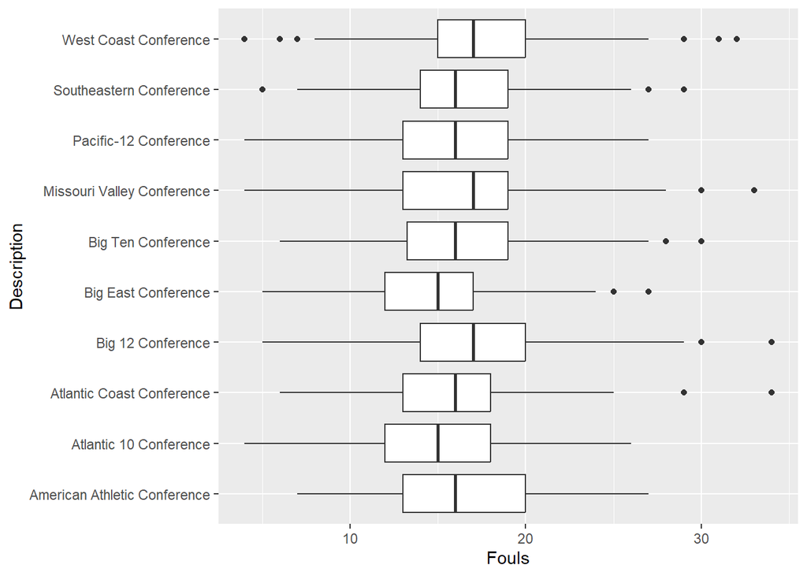

```r
# Fouls
w_all_gamedetails %>% ggplot(aes(x = Description, y = Fouls)) + geom_boxplot() + coord_flip()
```

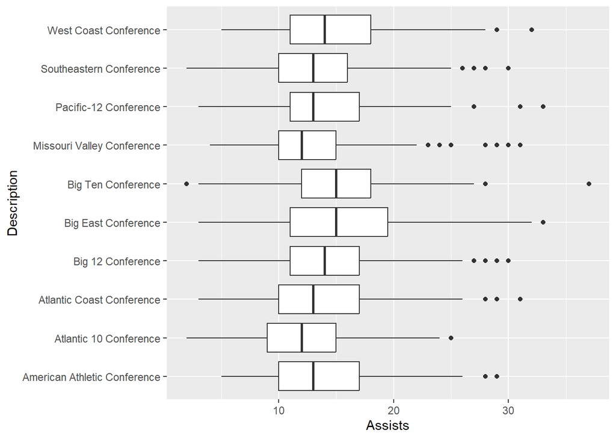

```r
# Assists
w_all_gamedetails %>% ggplot(aes(x = Description, y = Assists)) + geom_boxplot() + coord_flip()
```

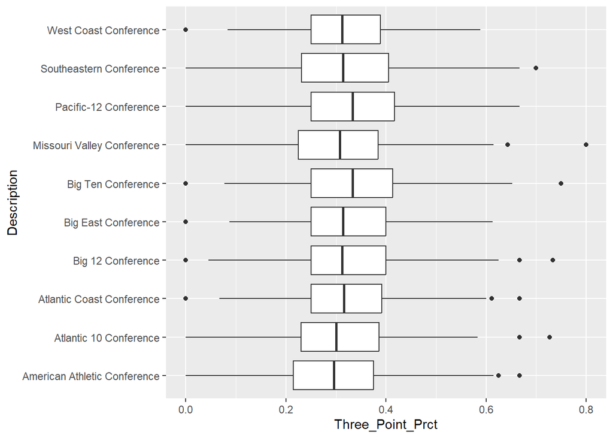

```r
# 3-Point Shooting %
w_all_gamedetails %>% ggplot(aes(x = Description, y = Three_Point_Prct)) + geom_boxplot() + coord_flip()
```

```r
# overall averages
w_category_avgs <- w_all_gamedetails %>% group_by(Description) %>% summarize(score = mean(Score), fouls = mean(Fouls), assists = mean(Assists), threept = mean(FGM3 / FGA3))
w_category_avgs
```

```
## # A tibble: 10 × 5
##    Description                  score fouls assists threept
##    <chr>                        <dbl> <dbl>   <dbl>   <dbl>
##  1 American Athletic Conference  62.7  16.5    13.5   0.294
##  2 Atlantic 10 Conference        62.3  15.2    12.5   0.311
##  3 Atlantic Coast Conference     67.3  15.7    13.7   0.317
##  4 Big 12 Conference             70.2  16.8    14.6   0.330
##  5 Big East Conference           68.2  14.7    15.4   0.314
##  6 Big Ten Conference            71.0  16.2    15.1   0.334
##  7 Missouri Valley Conference    63.8  16.6    12.8   0.307
##  8 Pacific-12 Conference         66.6  16.2    13.9   0.333
##  9 Southeastern Conference       69.6  16.3    13.6   0.319
## 10 West Coast Conference         67.8  17.6    14.6   0.313
```

Men (all conferences):

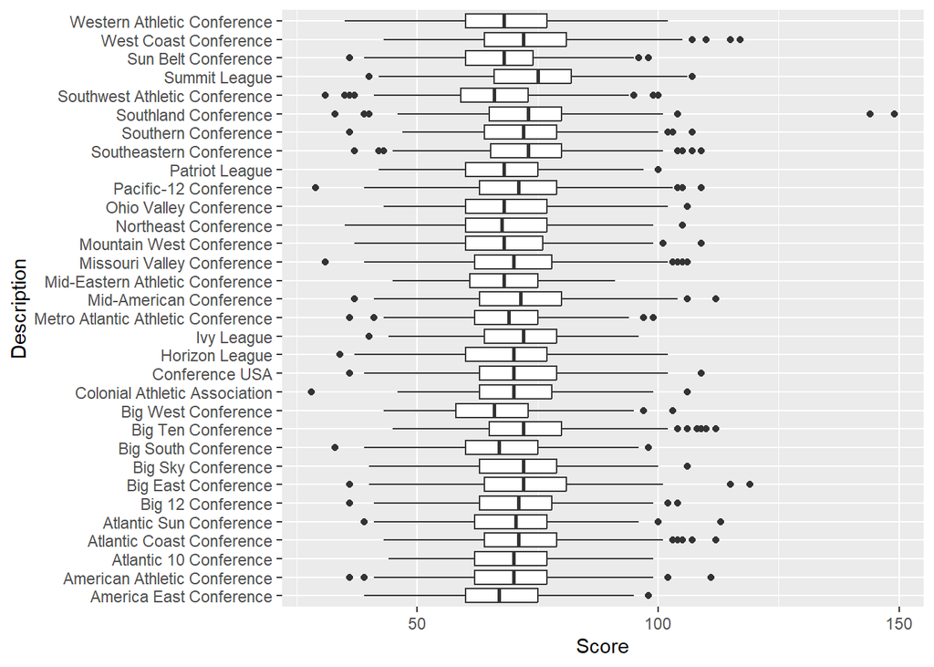

```r
m_teamsALL <- MTeamConferences %>% filter(Season == "2022") %>% select(TeamID, ConfAbbrev)

m_win_gamedetailsALL <- MRegularSeasonDetailedResults %>% filter(Season == "2022") %>% select(WTeamID, WScore, WPF, WAst, WFGM3, WFGA3) %>% inner_join(m_teamsALL, by = c("WTeamID" = "TeamID")) %>% left_join(conferences, by = c("ConfAbbrev" = "ConfAbbrev")) %>%
        rename("TeamID" = "WTeamID",
               "Score" = "WScore",
               "Fouls" = "WPF",
               "Assists" = "WAst",
               "FGM3" = "WFGM3",
               "FGA3" = "WFGA3")

m_lose_gamedetailsALL <- MRegularSeasonDetailedResults %>% filter(Season == "2022") %>% select(LTeamID, LScore, LPF, LAst, LFGM3, LFGA3) %>% inner_join(m_teamsALL, by = c("LTeamID" = "TeamID")) %>% left_join(conferences, by = c("ConfAbbrev" = "ConfAbbrev")) %>%
        rename("TeamID" = "LTeamID",
               "Score" = "LScore",
               "Fouls" = "LPF",
               "Assists" = "LAst",
               "FGM3" = "LFGM3",
               "FGA3" = "LFGA3")

m_all_gamedetailsALL <- rbind(m_win_gamedetailsALL, m_lose_gamedetailsALL) %>% mutate(Three_Point_Prct = FGM3 / FGA3)

# Score
m_all_gamedetailsALL %>% ggplot(aes(x = Description, y = Score)) + geom_boxplot() + coord_flip()
```

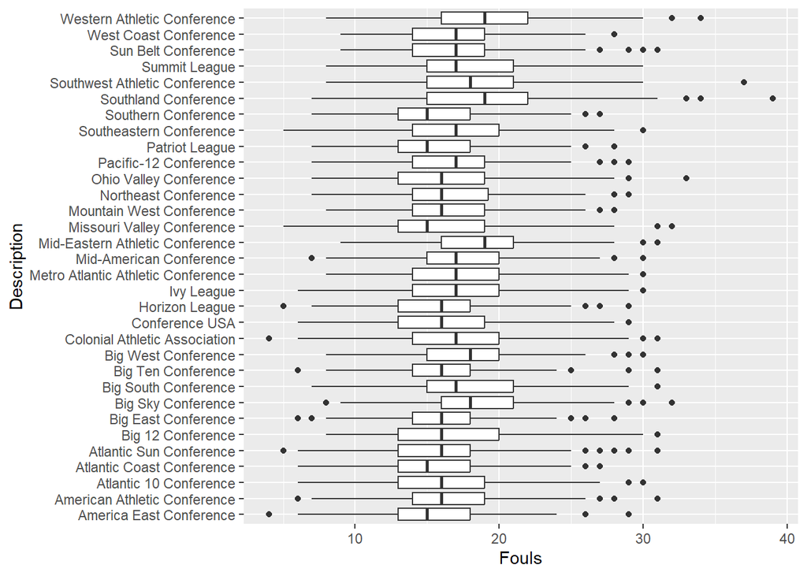

```r
# Fouls
m_all_gamedetailsALL %>% ggplot(aes(x = Description, y = Fouls)) + geom_boxplot() + coord_flip()
```

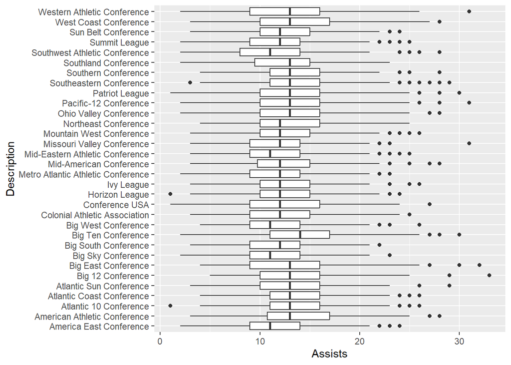

```r
# Assists
m_all_gamedetailsALL %>% ggplot(aes(x = Description, y = Assists)) + geom_boxplot() + coord_flip()
```

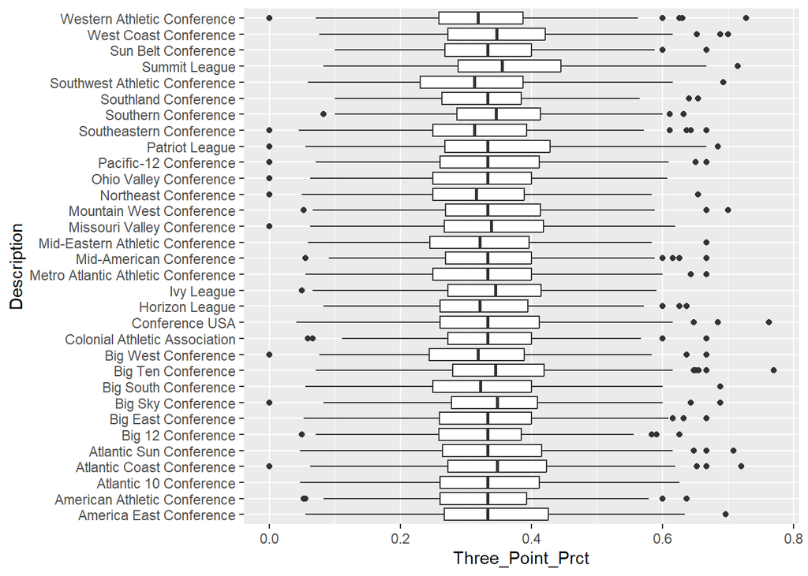

```r
# 3-Point Shooting %
m_all_gamedetailsALL %>% ggplot(aes(x = Description, y = Three_Point_Prct)) + geom_boxplot() + coord_flip()
```

```r
# overall averages
m_category_avgsALL <- m_all_gamedetailsALL %>% group_by(Description) %>% summarize(score = mean(Score), fouls = mean(Fouls), assists = mean(Assists), threept = mean(FGM3 / FGA3))
m_category_avgsALL
```

```
## # A tibble: 32 × 5
##    Description                  score fouls assists threept
##    <chr>                        <dbl> <dbl>   <dbl>   <dbl>
##  1 America East Conference       67.8  15.5    11.7   0.346
##  2 American Athletic Conference  69.8  16.8    13.6   0.329
##  3 Atlantic 10 Conference        69.7  16.1    13.4   0.341
##  4 Atlantic Coast Conference     71.6  15.3    13.7   0.348
##  5 Atlantic Sun Conference       69.9  15.8    13.1   0.341
##  6 Big 12 Conference             70.5  16.6    13.6   0.327
##  7 Big East Conference           72.3  16.1    13.3   0.332
##  8 Big Sky Conference            71.5  18.3    11.5   0.343
##  9 Big South Conference          67.4  17.6    12.0   0.326
## 10 Big Ten Conference            72.8  16.1    14.0   0.349
## # ℹ 22 more rows
```

Women (all conferences):

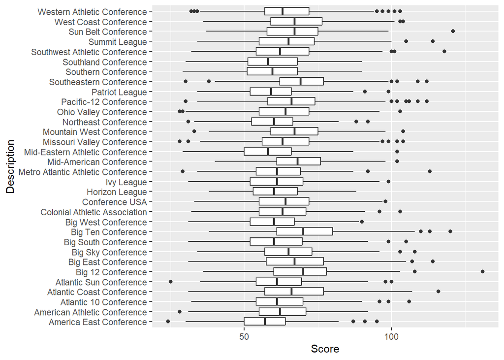

```r
w_teamsALL <- WTeamConferences %>% filter(Season == "2022") %>% select(TeamID, ConfAbbrev)

w_win_gamedetailsALL <- WRegularSeasonDetailedResults %>% filter(Season == "2022") %>% select(WTeamID, WScore, WPF, WAst, WFGM3, WFGA3) %>% inner_join(w_teamsALL, by = c("WTeamID" = "TeamID")) %>% left_join(conferences, by = c("ConfAbbrev" = "ConfAbbrev")) %>%
        rename("TeamID" = "WTeamID",
               "Score" = "WScore",
               "Fouls" = "WPF",
               "Assists" = "WAst",
               "FGM3" = "WFGM3",
               "FGA3" = "WFGA3")

w_lose_gamedetailsALL <- WRegularSeasonDetailedResults %>% filter(Season == "2022") %>% select(LTeamID, LScore, LPF, LAst, LFGM3, LFGA3) %>% inner_join(w_teamsALL, by = c("LTeamID" = "TeamID")) %>% left_join(conferences, by = c("ConfAbbrev" = "ConfAbbrev")) %>%
        rename("TeamID" = "LTeamID",
               "Score" = "LScore",
               "Fouls" = "LPF",
               "Assists" = "LAst",
               "FGM3" = "LFGM3",
               "FGA3" = "LFGA3")

w_all_gamedetailsALL <- rbind(w_win_gamedetailsALL, w_lose_gamedetailsALL) %>% mutate(Three_Point_Prct = FGM3 / FGA3)

# Score
w_all_gamedetailsALL %>% ggplot(aes(x = Description, y = Score)) + geom_boxplot() + coord_flip()
```

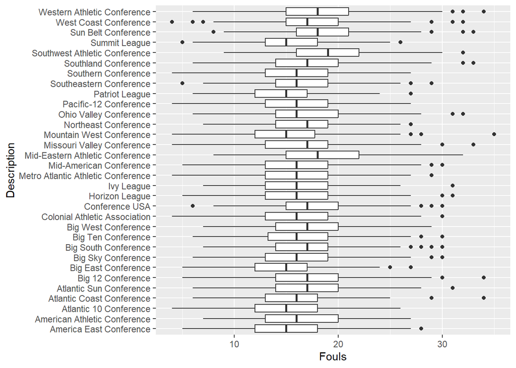

```r
# Fouls
w_all_gamedetailsALL %>% ggplot(aes(x = Description, y = Fouls)) + geom_boxplot() + coord_flip()
```

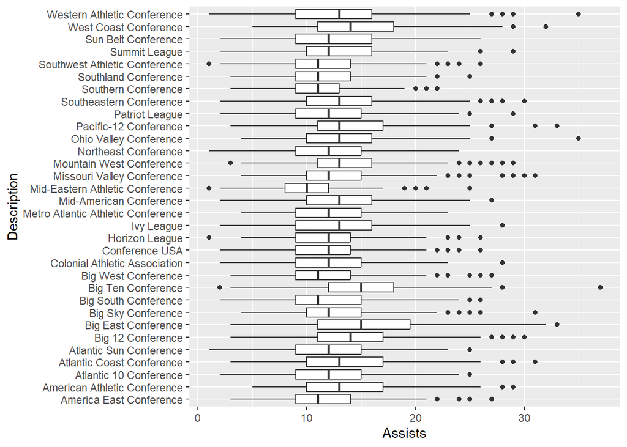

```r
# Assists
w_all_gamedetailsALL %>% ggplot(aes(x = Description, y = Assists)) + geom_boxplot() + coord_flip()
```

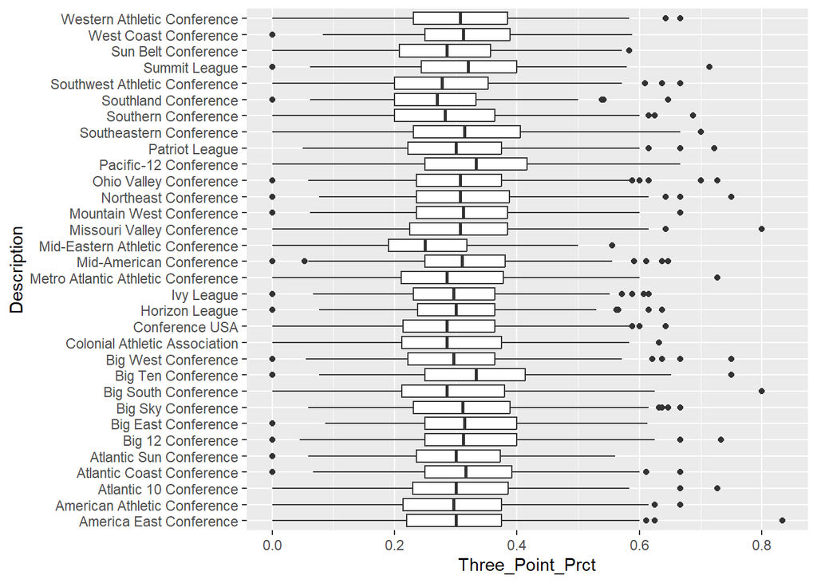

```r
# 3-Point Shooting %
w_all_gamedetailsALL %>% ggplot(aes(x = Description, y = Three_Point_Prct)) + geom_boxplot() + coord_flip()
```

```r
# overall averages
w_category_avgsALL <- w_all_gamedetailsALL %>% group_by(Description) %>% summarize(score = mean(Score), fouls = mean(Fouls), assists = mean(Assists), threept = mean(FGM3 / FGA3))
w_category_avgsALL
```

```
## # A tibble: 32 × 5
##    Description                  score fouls assists threept
##    <chr>                        <dbl> <dbl>   <dbl>   <dbl>
##  1 America East Conference       57.3  15.5    11.7   0.298
##  2 American Athletic Conference  62.7  16.5    13.5   0.294
##  3 Atlantic 10 Conference        62.3  15.2    12.5   0.311
##  4 Atlantic Coast Conference     67.3  15.7    13.7   0.317
##  5 Atlantic Sun Conference       62.0  17.1    12.0   0.298
##  6 Big 12 Conference             70.2  16.8    14.6   0.330
##  7 Big East Conference           68.2  14.7    15.4   0.314
##  8 Big Sky Conference            65.3  16.1    12.9   0.318
##  9 Big South Conference          61.3  16.8    12.1   0.294
## 10 Big Ten Conference            71.0  16.2    15.1   0.334
## # ℹ 22 more rows
```

## Q4: Which team is more likely to win an overtime game during the regular season (home or away)?

Men: Home team won overtime games 56.17% of the time.

```r
m_homewins <- MRegularSeasonDetailedResults %>% filter(NumOT > 0, WLoc == "H") %>% summarize(homecount = n())
m_homewins
```

```
##   homecount
## 1      3059
```

```r
m_awaywins <- MRegularSeasonDetailedResults %>% filter(NumOT > 0, WLoc == "A") %>% summarize(awaycount = n())
m_awaywins
```

```
##   awaycount
## 1      2387
```

```r
m_homewins / (m_homewins + m_awaywins)
```

```
##   homecount
## 1 0.5616967
```

Women: Home team won overtime games 53.98% of the time.

```r
w_homewins <- WRegularSeasonDetailedResults %>% filter(NumOT > 0, WLoc == "H") %>% summarize(homecount = n())
w_homewins
```

```
##   homecount
## 1      1538
```

```r
w_awaywins <- WRegularSeasonDetailedResults %>% filter(NumOT > 0, WLoc == "A") %>% summarize(awaycount = n())
w_awaywins
```

```
##   awaycount
## 1      1311
```

```r
w_homewins / (w_homewins + w_awaywins)
```

```
##   homecount
## 1 0.5398385
```

## Q5: What is the lowest seed to have won the championship game? What about getting to the Final Four?

Men: The lowest seed to have won the championship in the provided years is Connecticut in 2014 as a 7 seed. The lowest seeds to have made it to the final four are George Mason in 2006, VCU in 2011, Loyola-Chicago in 2018, and UCLA in 2021, all 11 seeds.

```r
# won champsionship
m_championshipgames <- MNCAATourneyDetailedResults %>% arrange(-DayNum) %>% filter(DayNum == 154) %>% select(Season, WTeamID) %>% left_join(MNCAATourneySeeds, by = c("Season" = "Season", "WTeamID" = "TeamID")) %>% left_join(MTeams, by = c("WTeamID" = "TeamID")) %>% select(Season, WTeamID, Seed, TeamName)
m_championshipgames
```

```
##    Season WTeamID Seed       TeamName
## 1    2003    1393  W03       Syracuse
## 2    2004    1163  X02    Connecticut
## 3    2005    1314  Z01 North Carolina
## 4    2006    1196  Y03        Florida
## 5    2007    1196  Y01        Florida
## 6    2008    1242  X01         Kansas
## 7    2009    1314  X01 North Carolina
## 8    2010    1181  X01           Duke
## 9    2011    1163  X03    Connecticut
## 10   2012    1246  Y01       Kentucky
## 11   2013    1257  Y01     Louisville
## 12   2014    1163  W07    Connecticut
## 13   2015    1181  X01           Duke
## 14   2016    1437  Y02      Villanova
## 15   2017    1314  Z01 North Carolina
## 16   2018    1437  W01      Villanova
## 17   2019    1438  Z01       Virginia
## 18   2021    1124  Z01         Baylor
## 19   2022    1242  Y01         Kansas
```

```r
# made it to final four
m_finalfourW <- MNCAATourneyDetailedResults %>% arrange(-DayNum) %>% select(Season, WTeamID, DayNum) %>% filter(DayNum == 152) %>% left_join(MNCAATourneySeeds, by = c("Season" = "Season", "WTeamID" = "TeamID")) %>% left_join(MTeams, by = c("WTeamID" = "TeamID")) %>% select(Season, WTeamID, Seed, TeamName) %>% rename("TeamID" = "WTeamID")
m_finalfourL <- MNCAATourneyDetailedResults %>% arrange(-DayNum) %>% select(Season, LTeamID, DayNum) %>% filter(DayNum == 152) %>% left_join(MNCAATourneySeeds, by = c("Season" = "Season", "LTeamID" = "TeamID")) %>% left_join(MTeams, by = c("LTeamID" = "TeamID")) %>% select(Season, LTeamID, Seed, TeamName) %>% rename("TeamID" = "LTeamID")

m_allfinal4 <- rbind(m_finalfourW, m_finalfourL) %>% arrange(Season)
m_allfinal4
```

```
##    Season TeamID Seed       TeamName
## 1    2003   1242  Z02         Kansas
## 2    2003   1393  W03       Syracuse
## 3    2003   1266  Y03      Marquette
## 4    2003   1400  X01          Texas
## 5    2004   1163  X02    Connecticut
## 6    2004   1210  Z03   Georgia Tech
## 7    2004   1181  W01           Duke
## 8    2004   1329  Y02    Oklahoma St
## 9    2005   1228  X01       Illinois
## 10   2005   1314  Z01 North Carolina
## 11   2005   1257  W04     Louisville
## 12   2005   1277  Y05    Michigan St
## 13   2006   1196  Y03        Florida
## 14   2006   1417  X02           UCLA
```

[output cut: 62 more lines]

Women: The lowest seed to have won the championship in the provided years is Texas A&M in 2011 as a 2 seed. All other championships have been won by a 1 seed. The lowest seed to have made it to the final four is Washington in 2016 as a 7 seed.

```r
# championship game was day155 for 2010-2016, but day153 for 2017-2022
w_championshipgames1 <- WNCAATourneyDetailedResults %>% arrange(-DayNum) %>% select(Season, WTeamID, DayNum) %>% filter(DayNum == 155) %>% left_join(WNCAATourneySeeds, by = c("Season" = "Season", "WTeamID" = "TeamID")) %>% left_join(WTeams, by = c("WTeamID" = "TeamID")) %>% select(Season, WTeamID, Seed, TeamName)
w_championshipgames2 <- WNCAATourneyDetailedResults %>% arrange(-DayNum) %>% select(Season, WTeamID, DayNum) %>% filter(Season %in% c(2017:2022), DayNum == 153) %>% left_join(WNCAATourneySeeds, by = c("Season" = "Season", "WTeamID" = "TeamID")) %>% left_join(WTeams, by = c("WTeamID" = "TeamID")) %>% select(Season, WTeamID, Seed, TeamName)
w_championshipgames <- rbind(w_championshipgames1, w_championshipgames2) %>% arrange(Season)
w_championshipgames
```

```
##    Season WTeamID Seed       TeamName
## 1    2010    3163  W01    Connecticut
## 2    2011    3401  W02      Texas A&M
## 3    2012    3124  W01         Baylor
## 4    2013    3163  W01    Connecticut
## 5    2014    3163  W01    Connecticut
## 6    2015    3163  W01    Connecticut
## 7    2016    3163  W01    Connecticut
## 8    2017    3376  Z01 South Carolina
## 9    2018    3323  X01     Notre Dame
## 10   2019    3124  Y01         Baylor
## 11   2021    3390  W01       Stanford
## 12   2022    3376  Y01 South Carolina
```

```r
# made it to final four
# final four was day 153 for 2010-2016
w_finalfourW1 <- WNCAATourneyDetailedResults %>% arrange(-DayNum) %>% select(Season, WTeamID, DayNum) %>% filter(Season <= 2016, DayNum == 153) %>% left_join(WNCAATourneySeeds, by = c("Season" = "Season", "WTeamID" = "TeamID")) %>% left_join(WTeams, by = c("WTeamID" = "TeamID")) %>% select(Season, WTeamID, Seed, TeamName) %>% rename("TeamID" = "WTeamID")

w_finalfourL1 <- WNCAATourneyDetailedResults %>% arrange(-DayNum) %>% select(Season, LTeamID, DayNum) %>% filter(Season <= 2016, DayNum == 153) %>% left_join(WNCAATourneySeeds, by = c("Season" = "Season", "LTeamID" = "TeamID")) %>% left_join(WTeams, by = c("LTeamID" = "TeamID")) %>% select(Season, LTeamID, Seed, TeamName) %>% rename("TeamID" = "LTeamID")
# 2010-2016
w_allfinal41 <- rbind(w_finalfourW1, w_finalfourL1) %>% arrange(Season)

# final four was day151 for 2017-2022
w_finalfourW2 <- WNCAATourneyDetailedResults %>% arrange(-DayNum) %>% select(Season, WTeamID, DayNum) %>% filter(Season > 2016, DayNum == 151) %>% left_join(WNCAATourneySeeds, by = c("Season" = "Season", "WTeamID" = "TeamID")) %>% left_join(WTeams, by = c("WTeamID" = "TeamID")) %>% select(Season, WTeamID, Seed, TeamName) %>% rename("TeamID" = "WTeamID")

w_finalfourL2 <- WNCAATourneyDetailedResults %>% arrange(-DayNum) %>% select(Season, LTeamID, DayNum) %>% filter(Season > 2016, DayNum == 151) %>% left_join(WNCAATourneySeeds, by = c("Season" = "Season", "LTeamID" = "TeamID")) %>% left_join(WTeams, by = c("LTeamID" = "TeamID")) %>% select(Season, LTeamID, Seed, TeamName) %>% rename("TeamID" = "LTeamID")
# 2017-2022
w_allfinal42 <-  rbind(w_finalfourW2, w_finalfourL2) %>% arrange(Season)

# all final four teams
w_allfinal4 <- rbind(w_allfinal41, w_allfinal42) %>% arrange(Season)
w_allfinal4
```

```
##    Season TeamID Seed       TeamName
## 1    2010   3163  W01    Connecticut
## 2    2010   3390  Z01       Stanford
## 3    2010   3124  X04         Baylor
## 4    2010   3328  Y03       Oklahoma
## 5    2011   3323  Y02     Notre Dame
## 6    2011   3401  W02      Texas A&M
## 7    2011   3163  Z01    Connecticut
## 8    2011   3390  X01       Stanford
## 9    2012   3124  W01         Baylor
## 10   2012   3323  Z01     Notre Dame
## 11   2012   3390  X01       Stanford
## 12   2012   3163  Y01    Connecticut
## 13   2013   3163  W01    Connecticut
## 14   2013   3257  Y05     Louisville
```

[output cut: 34 more lines]

## Chip’s Question: Compare freethrow percentages between years. Has the average freethrow percentage increased, decreased, or stayed about the same?

Men:

```r
# added winning team ft made to losing team ft made. divided by winning and losing attempted ft sum to get overall ft percentage for each game.
game_ft_perct <- MRegularSeasonDetailedResults %>% select(Season, WFTM, WFTA, LFTM, LFTA) %>% mutate(ft_perct = (WFTM + LFTM) / (WFTA + LFTA))
game_ft_perct %>% head()
```

```
##   Season WFTM WFTA LFTM LFTA  ft_perct
## 1   2003   11   18   16   22 0.6750000
## 2   2003   10   19    9   20 0.4871795
## 3   2003   17   29   14   23 0.5961538
## 4   2003   17   31    8   15 0.5434783
## 5   2003   11   13   17   27 0.7000000
## 6   2003   23   27   12   17 0.7954545
```

```r
season_avg <- game_ft_perct %>% group_by(Season) %>% summarize(avg_ft_perct_year = mean(ft_perct))
season_avg
```

```
## # A tibble: 21 × 2
##    Season avg_ft_perct_year
##     <int>             <dbl>
##  1   2003             0.693
##  2   2004             0.686
##  3   2005             0.686
##  4   2006             0.691
##  5   2007             0.690
##  6   2008             0.690
##  7   2009             0.688
##  8   2010             0.688
##  9   2011             0.691
## 10   2012             0.690
## # ℹ 11 more rows
```

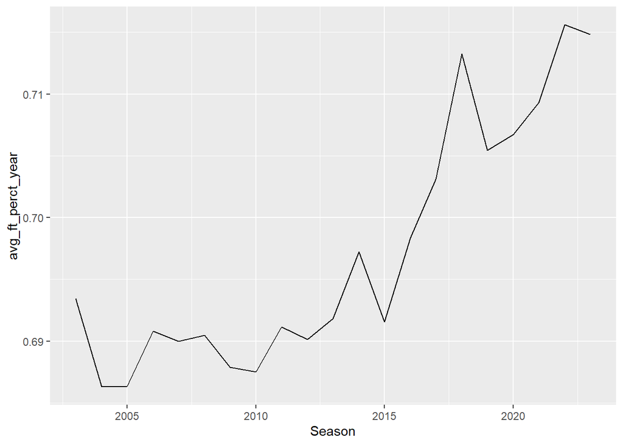

```r
season_avg %>% ggplot(aes(x = Season, y = avg_ft_perct_year)) + geom_line()
```

```r
# so ft percentage did increase, but only by 2%
```

Women:

```r
game_ft_perct <- WRegularSeasonDetailedResults %>% select(Season, WFTM, WFTA, LFTM, LFTA) %>% mutate(ft_perct = (WFTM + LFTM) / (WFTA + LFTA))
game_ft_perct %>% head()
```

```
##   Season WFTM WFTA LFTM LFTA  ft_perct
## 1   2010   12   19    6   10 0.6206897
## 2   2010   16   28   14   27 0.5454545
## 3   2010    7   12   19   23 0.7428571
## 4   2010    5    9   16   25 0.6176471
## 5   2010    7   11   11   21 0.5625000
## 6   2010   23   36   15   29 0.5846154
```

```r
season_avg <- game_ft_perct %>% group_by(Season) %>% summarize(avg_ft_perct_year = mean(ft_perct))
season_avg
```

```
## # A tibble: 14 × 2
##    Season avg_ft_perct_year
##     <int>             <dbl>
##  1   2010             0.688
##  2   2011             0.687
##  3   2012             0.689
##  4   2013             0.689
##  5   2014             0.693
##  6   2015             0.688
##  7   2016             0.697
##  8   2017             0.696
##  9   2018             0.701
## 10   2019             0.693
## 11   2020             0.695
## 12   2021             0.702
## 13   2022             0.706
## 14   2023             0.710
```

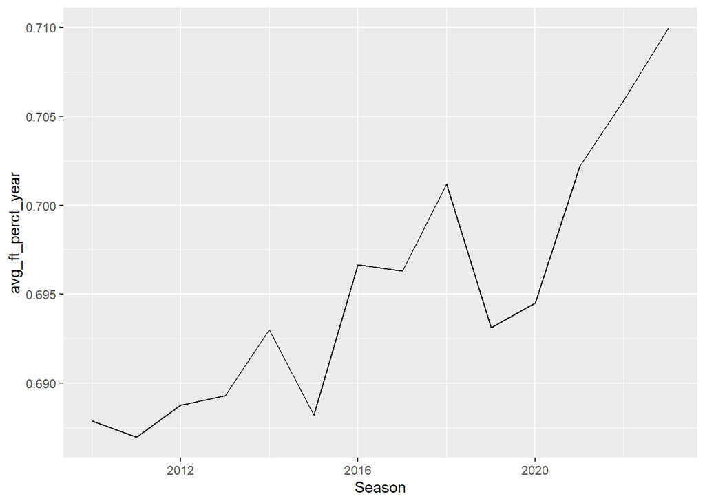

```r
season_avg %>% ggplot(aes(x = Season, y = avg_ft_perct_year)) + geom_line()
```